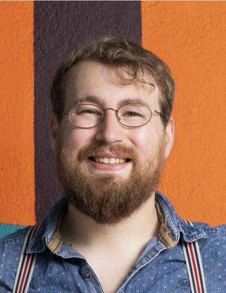

# Thomaz F. S. Bastiaanssen, PhD

**Summary** (click headers to expand)

The focus of my research currently lies in understanding microbiome-gut-brain communication from a theoretical ecology/bioinformatics perspective. In particular, I am interested in understanding the role of stability and volatility of the gut microbiome in anxiety and depression and in integrating different types of ’omics data in a biologically interpretable manner.

As a bioinformatician, I value clear and easily interpretable analysis of complex data in order to promote interdisciplinary collaboration. After working as the lead bioinformatician in Prof. Cryans lab in Cork, Ireland, I transitioned to a new position in Amsterdam UMC with Prof. Brenda Penninx in 2024.

- Supervision of Prof. John F. Cryan, Prof. Timothy G. Dinan and Dr. Marcus J. Claesson

**Utrecht University** | Utrecht, Netherlands  
MSc | 2014 - 2017

- Trajectory: Molecular and Cellular Life Sciences - Bioinformatics

BSc | 2010 - 2013

- Major in Biology with a Minor in Art History

- Microbiome Bioinformatician

**APC Microbiome Ireland** | Cork, Ireland  
Postdoctoral Researcher | March 2021 - March 2024

- Lead Bioinformatician

[figure not shown]